# Text Analysis: Topic Models and LSA

# About the Data

This dataset is based on a set of Amazon review of video games downloaded from Prof Julian McAuley’s [website](http://jmcauley.ucsd.edu/data/amazon/). The original json dataset was parsed into a dataframe and cleaned. Since this dataset is very large, I have only included data from Aug 2013 to July 2014 which gives us a year of data to work with. Also we are only using data on three fields, id, review and review rating. Finally, three blank reviews were dropped from the data. The data we are going to use includes the following fields:

- id: A unique identifier for each review
- review: Text of review posted on Amazon
- review_rating: Each review on Amazon is rated by others using a five-star scale (presumably based on helpfulness of review)

# Read Data

You must read the data before trying to run the code on your own machine. To read data use the following code after setting your working directory. To set your working directory, modify the following to set the file path for the folder where the data file resides. setwd(’c:/thatawesomeclass/)

```r
videogame = read.csv('video_game_reviews.csv',stringsAsFactors = F)
```

# Clean and Tokenize

There are many ways to quantify text. Here, we will use the bag of words approach where we first clean the data and then extract individual words, a process known as tokenization. Specifically, we will create a corpus, clean the text, and generate a matrix derived from term frequencies. 1. Create a corpus from the variable ‘review’  
2. Use tm_map to  
(a) transform text to lower case,  
(b) remove punctuation,  
(c) remove English stopwords using the following dictionary tm::stopwords(’english)  
(d) remove urls (e) remove whitespace  
3. Create a dictionary  
4. Use tm_map to stem words  
5. Create a DocumentTermMatrix

```r
library(tm); library(SnowballC); library(magrittr)
corpus = Corpus(VectorSource(videogame$review))
corpus =
  corpus%>%
  tm_map(content_transformer(tolower))%>%
  tm_map(content_transformer(FUN = function(x)gsub(pattern = 'http[[:alnum:][:punct:]]*',
                                                   replacement = ' ',x = x)))%>%
  tm_map(removePunctuation)%>%
  tm_map(removeWords, c(stopwords('english'),'game','play','gaming','games',
                        'player','players','playing', 'played'))

dict = findFreqTerms(DocumentTermMatrix(Corpus(VectorSource(videogame$review))),lowfreq = 0)
dict_corpus = Corpus(VectorSource(dict))

corpus =
  corpus %>%
  tm_map(stemDocument)%>%
  tm_map(stripWhitespace)

dtm = DocumentTermMatrix(corpus)
xdtm = removeSparseTerms(dtm,sparse = 0.95)
xdtm = as.data.frame(as.matrix(xdtm))
colnames(xdtm) = stemCompletion(x = colnames(xdtm),dictionary = dict_corpus,type = 'prevalent')
colnames(xdtm) = make.names(colnames(xdtm))
```

# Topic Model

Topic models can only work with non-zero documents, so remove documents with all zeros.

```r
which(rowSums(xdtm)==0) # documents with all zeros
```

```
##    80   162   177   360   457   544   593   971  1098  1372  1451  1643  1789
##    80   162   177   360   457   544   593   971  1098  1372  1451  1643  1789
##  1794  1910  2075  2267  2309  2468  2541  3838  3935  4016  4239  4483  4586
##  1794  1910  2075  2267  2309  2468  2541  3838  3935  4016  4239  4483  4586
##  4660  4820  4929  4963  5069  5122  5319  5477  5744  5789  6083  6139  6167
##  4660  4820  4929  4963  5069  5122  5319  5477  5744  5789  6083  6139  6167
##  6365  6411  6602  6631  6742  6950  7022  7066  7227  7315  7531  7532  7557
##  6365  6411  6602  6631  6742  6950  7022  7066  7227  7315  7531  7532  7557
##  7666  7841  8092  8117  8158  8252  8334  9883  9899 10207 10220 10374 10683
##  7666  7841  8092  8117  8158  8252  8334  9883  9899 10207 10220 10374 10683
## 10733 10745 10957 10999 11104 11381 11815 12314 12407 13088 13125 13565 13647
## 10733 10745 10957 10999 11104 11381 11815 12314 12407 13088 13125 13565 13647
## 13742 13797 13951 13954 14066 14171 14286 14430 15113 15811 15818 17102 17132
## 13742 13797 13951 13954 14066 14171 14286 14430 15113 15811 15818 17102 17132
## 17279 17322 17436 17675 18732 18816 19011 19042 19571 20032 20725 20906 21191
## 17279 17322 17436 17675 18732 18816 19011 19042 19571 20032 20725 20906 21191
## 21245 21294 21759 21935 21958 22268 23176 23241 24585 24722 24899 25137 25634
## 21245 21294 21759 21935 21958 22268 23176 23241 24585 24722 24899 25137 25634
## 25718 25742 25817 25888
## 25718 25742 25817 25888
```

```r
xdtm_topic = xdtm[which(rowSums(xdtm)!=0),]
```

Run Topic Model with two topics using function defaults.

```r
library(topicmodels)
set.seed(617)
topic2 = LDA(x = xdtm_topic,k = 2)
```

Explore term-topic probabilities using tm functions

```r
terms(topic2,10) # top 10 terms included in each topic
```

```
##       Topic 1    Topic 2
##  [1,] "one"      "like"
##  [2,] "reallisc" "time"
##  [3,] "use"      "can"
##  [4,] "get"      "get"
##  [5,] "fun"      "great"
##  [6,] "just"     "just"
##  [7,] "make"     "one"
##  [8,] "can"      "control"
##  [9,] "will"     "love"
## [10,] "much"     "storie"
```

```r
length(unique(topic2@terms))
```

```
## [1] 155
```

```r
length(topic2@terms)
```

```
## [1] 155
```

```r
# exp(topic2@beta) # term topic probabilities
# topic2@terms # list of all terms
df_beta = data.frame(t(exp(topic2@beta)),row.names = topic2@terms)
colnames(df_beta) = c('topic1','topic2')
df_beta[1:20,] # term - topic probabilities
```

|  | topic1 | topic2 |
| --- | --- | --- |
| can | 0.020730031 | 0.027269989 |
| good | 0.019177464 | 0.011711690 |
| got | 0.010835333 | 0.001985760 |
| nother | 0.004395041 | 0.001293967 |
| one | 0.031808658 | 0.018934300 |
| bad | 0.006559298 | 0.002089760 |
| didnt | 0.004063150 | 0.004807023 |
| dont | 0.010038811 | 0.011639176 |
| everythime.the | 0.004775375 | 0.001843355 |
| first | 0.006458241 | 0.013879101 |

[output cut: 10 more lines]

Visualize Term-Topic probabilities

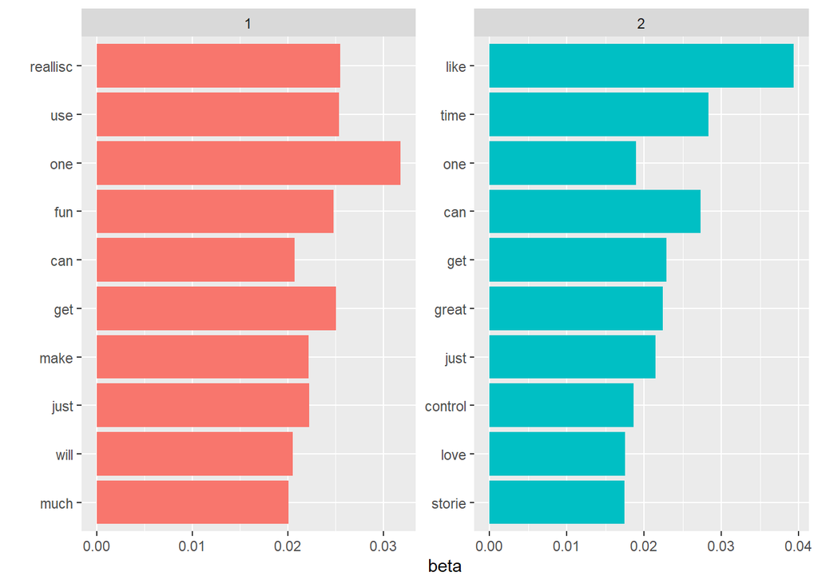

```r
library(tidytext); library(dplyr); library(ggplot2); library(tidyr)
topic2 %>%
  tidy(matrix='beta')%>%
  group_by(topic)%>%
  top_n(n = 10,wt=beta)%>%
  ungroup()%>%
  ggplot(aes(x=reorder(term,beta),y=beta,fill=factor(topic)))+
  geom_bar(position='dodge', stat='identity')+
  facet_wrap(~topic, scales = 'free')+
  coord_flip()+guides(fill=F)+xlab('')
```

Terms/words that differ the most across topics. Compare betas and only keep beta_spread values that are outside of +/- 2*sd from mean.

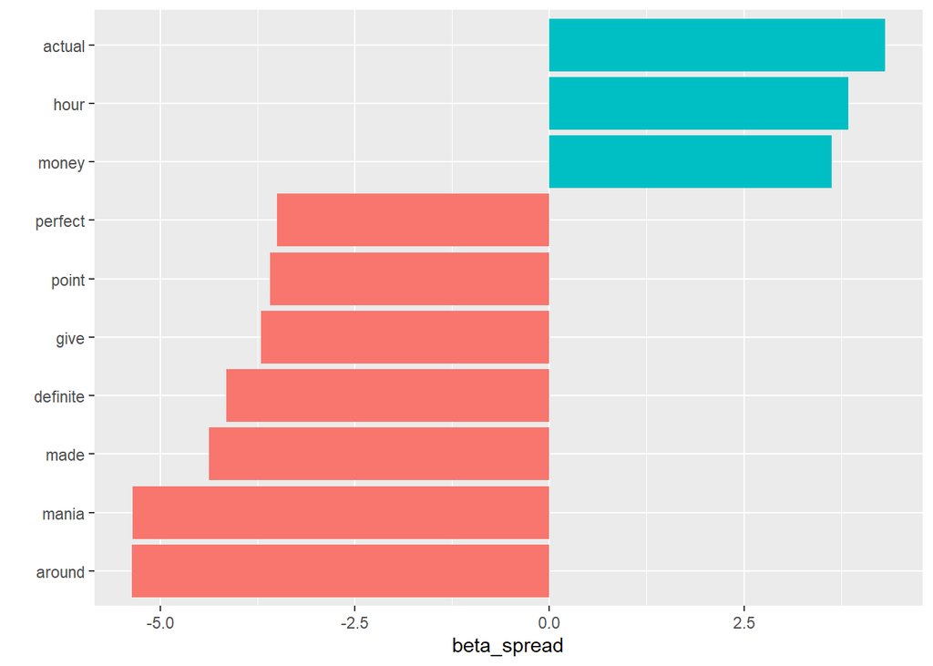

```r
topic2%>%
  tidy(matrix='beta')%>%
  mutate(topic = paste0("topic_",topic))%>%
  spread(key = topic,value = beta)%>%
  mutate(beta_spread = log(topic_1/topic_2,2))%>%
  filter(beta_spread>mean(beta_spread)+2*sd(beta_spread)|beta_spread<mean(beta_spread)-2*sd(beta_spread))%>%
  ggplot(aes(x=reorder(term, beta_spread),y=beta_spread, fill=factor(beta_spread>0)))+
  geom_col()+
  coord_flip()+guides(fill=F)+xlab('')
```

Document-Topic probabilities

```r
# topic2@gamma # document topic probabilities
df_gamma = cbind(as.integer(topic2@documents), topic2@gamma)
colnames(df_gamma) = c('id','topic1','topic2')
df_gamma[1:10,]  # Document probabilities for first 10 documents
```

```
##       id    topic1    topic2
##  [1,]  1 0.5124546 0.4875454
##  [2,]  2 0.4942606 0.5057394
##  [3,]  3 0.4999825 0.5000175
##  [4,]  4 0.4929939 0.5070061
##  [5,]  5 0.5011674 0.4988326
##  [6,]  6 0.4803680 0.5196320
##  [7,]  7 0.5002920 0.4997080
##  [8,]  8 0.4956300 0.5043700
##  [9,]  9 0.4939041 0.5060959
## [10,] 10 0.4854656 0.5145344
```

Visualize document-topic probabilities for first 20 documents.

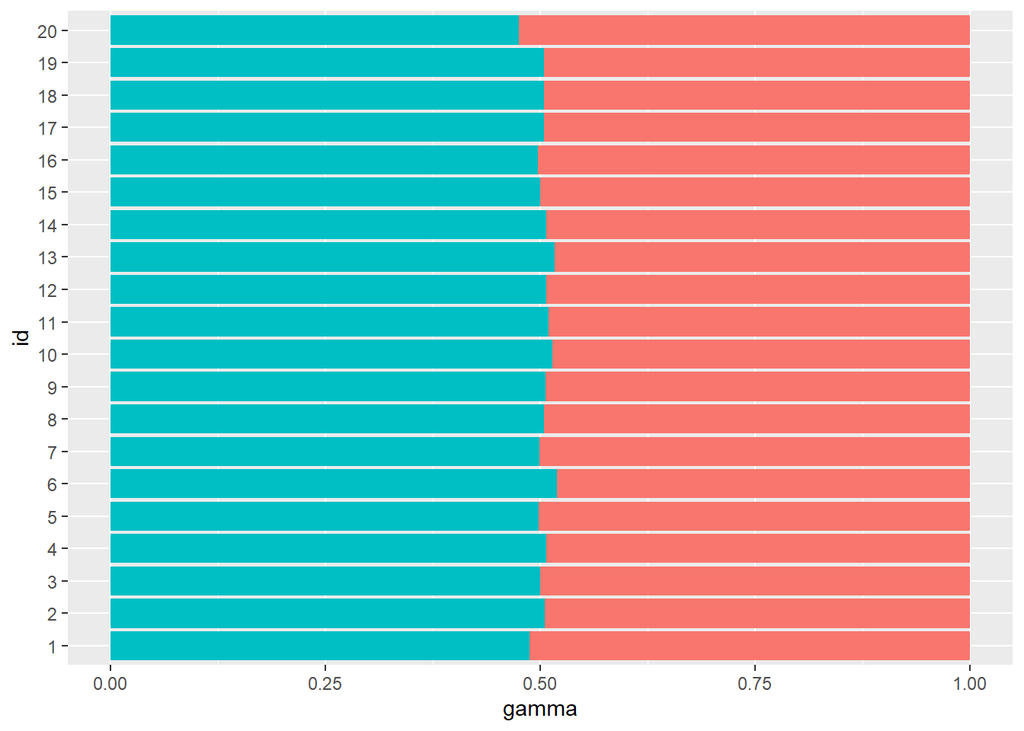

```r
library(tidytext); library(dplyr); library(ggplot2); library(tidyr)
topic2%>%
  tidy('gamma')%>%
  filter(as.integer(document)<=20)%>%
  ggplot(aes(x=reorder(document,as.numeric(document)),y=gamma,fill=factor(topic)))+
  geom_bar(position='fill',stat='identity')+xlab('id')+guides(fill=F)+coord_flip()
```

Combine topics with original data

```r
text_topics = cbind(as.integer(topic2@documents),topic2@gamma)
colnames(text_topics) = c('id','topic1','topic2')
text_topics = merge(x = text_topics,y = videogame[,c(1,3)],by=c('id','id'))
head(text_topics)
```

|  | id | topic1 | topic2 | review_rating |
| --- | --- | --- | --- | --- |
| 1 | 1 | 0.5124546 | 0.4875454 | 1 |
| 2 | 2 | 0.4942606 | 0.5057394 | 2 |
| 3 | 3 | 0.4999825 | 0.5000175 | 1 |
| 4 | 4 | 0.4929939 | 0.5070061 | 5 |
| 5 | 5 | 0.5011674 | 0.4988326 | 5 |
| 6 | 6 | 0.4803680 | 0.5196320 | 1 |

Predictive Model

```r
text_topics = cbind(as.integer(topic2@documents),topic2@gamma)
colnames(text_topics) = c('id','topic1','topic2')
text_topics = merge(x = text_topics,y = videogame[,c(1,3)],by=c('id','id'))
head(text_topics)
```

|  | id | topic1 | topic2 | review_rating |
| --- | --- | --- | --- | --- |
| 1 | 1 | 0.5124546 | 0.4875454 | 1 |
| 2 | 2 | 0.4942606 | 0.5057394 | 2 |
| 3 | 3 | 0.4999825 | 0.5000175 | 1 |
| 4 | 4 | 0.4929939 | 0.5070061 | 5 |
| 5 | 5 | 0.5011674 | 0.4988326 | 5 |
| 6 | 6 | 0.4803680 | 0.5196320 | 1 |

```r
set.seed(617)
split = sample(1:nrow(text_topics),size = 0.7*nrow(text_topics))
train = text_topics[split,]
test = text_topics[-split,]

library(rpart)
model = rpart(review_rating~.-id,train)
pred = predict(model,newdata = test)
sqrt(mean((pred-test$review_rating)^2))
```

```
## [1] 1.195386
```

# Latent Semantic Analysis

```r
library(lsa)
clusters = lsa(xdtm)
# lsa decomposes data into three matrices. The term matrix contains the dimensions from svd
clusters$tk = as.data.frame(clusters$tk)
colnames(clusters$tk) = paste0("dim",1:51)
head(clusters$tk)
```

|  | dim1 | dim2 | dim3 | dim4 | dim5 | dim6 | dim7 | dim8 | dim9 | dim10 | dim11 | dim12 | dim13 | dim14 | dim15 | dim16 | dim17 | dim18 | dim19 | dim20 | dim21 | dim22 | dim23 | dim24 | dim25 | dim26 | dim27 | dim28 | dim29 | … |
| --- | --- | --- | --- | --- | --- | --- | --- | --- | --- | --- | --- | --- | --- | --- | --- | --- | --- | --- | --- | --- | --- | --- | --- | --- | --- | --- | --- | --- | --- | --- |
| 1 | -0.0011171861 | 0.0006283973 | 0.0019243039 | 0.0025229561 | 1.228968e-03 | -0.003534960 | -0.0007899519 | 0.0037186892 | -0.0002187441 | 0.0001057618 | -0.0007562141 | 0.0009164378 | -0.0022201837 | 0.0031501395 | 0.0001514118 | 0.004829151 | 0.006300256 | 0.001727317 | -0.0012612297 | -0.001680265 | 0.0027135923 | 0.0024150926 | 0.0018970358 | 0.0013846238 | -0.001159918 | 0.0013611811 | 0.0001790210 | -0.0009408148 | -0.0013572579 | … |
| 2 | -0.0042263805 | 0.0036941371 | -0.0078609524 | -0.0028293079 | 1.038900e-02 | -0.003889389 | -0.0018527373 | 0.0027810687 | 0.0088990834 | -0.0022450618 | 0.0070617337 | -0.0031799414 | 0.0001778381 | 0.0025055915 | -0.0130965459 | -0.001961823 | 0.002923769 | 0.008270187 | 0.0031804506 | -0.001019264 | -0.0005187887 | -0.0016244441 | 0.0086851796 | 0.0040557965 | 0.007765796 | 0.0050876400 | -0.0021943608 | 0.0049985091 | -0.0027539275 | … |
| 3 | -0.0004996325 | 0.0010505528 | -0.0007372235 | -0.0008485787 | 1.591463e-05 | 0.000986910 | 0.0004537868 | 0.0008505529 | -0.0022271073 | -0.0004450939 | 0.0018364778 | 0.0003625249 | -0.0010538725 | -0.0005946309 | 0.0008652790 | 0.003733912 | 0.004790064 | 0.001226648 | -0.0020625958 | -0.001136086 | -0.0007164615 | -0.0002014045 | 0.0045851755 | 0.0051020636 | 0.002806841 | 0.0020764100 | 0.0007892835 | -0.0020612523 | -0.0022839472 | … |
| 4 | -0.0010500281 | 0.0010733899 | 0.0008215093 | -0.0011525409 | -3.640169e-04 | 0.002070998 | 0.0002788663 | -0.0013171406 | -0.0030567913 | -0.0037242827 | 0.0042406208 | 0.0006421856 | -0.0033596016 | 0.0010650962 | 0.0036086076 | 0.001471901 | -0.008931867 | 0.001065945 | -0.0025350392 | -0.002948618 | 0.0037166497 | 0.0021515274 | 0.0025876864 | 0.0053264300 | 0.001960590 | -0.0024770427 | -0.0020030097 | -0.0045607105 | -0.0047327197 | … |
| 5 | -0.0009968138 | -0.0010192219 | -0.0027882781 | -0.0011112829 | 2.460239e-03 | 0.001349688 | -0.0014650345 | 0.0046517456 | 0.0011799064 | 0.0037414071 | 0.0052296159 | -0.0008364928 | -0.0011940028 | 0.0028669492 | 0.0034214640 | 0.001342820 | -0.005862532 | -0.005970549 | 0.0030357095 | 0.001721309 | 0.0034375640 | 0.0012096048 | 0.0020111336 | -0.0001852464 | 0.001984743 | -0.0054442259 | -0.0028331245 | -0.0045515235 | -0.0004780894 | … |
| 6 | -0.0136890351 | -0.0011813365 | 0.0019661055 | -0.0039077612 | -5.080968e-03 | 0.013114074 | -0.0052182826 | -0.0072789535 | 0.0140077323 | 0.0132966855 | -0.0115998954 | 0.0225235824 | -0.0077170822 | -0.0086697142 | -0.0076617625 | -0.003344863 | 0.002459745 | 0.015613537 | -0.0006209831 | -0.012575382 | -0.0003030128 | -0.0033836952 | -0.0005702615 | -0.0145435417 | -0.011389182 | -0.0005511301 | 0.0175381495 | -0.0156689516 | 0.0157418808 | … |

Predictive Model

```r
clusters_data = cbind(id = videogame$id, review_rating = videogame$review_rating,clusters$tk)

set.seed(617)
split = sample(1:nrow(clusters_data),size = 0.7*nrow(clusters_data))
train = clusters_data[split,]
test = clusters_data[-split,]

model = rpart(review_rating~.-id,train)
pred = predict(model,newdata = test)
sqrt(mean((pred-test$review_rating)^2))
```

```
## [1] 1.157888
```

This file was generated using R Version 4.1.2